[figure not shown]

# 04 Prepare : Reading

## Objectives

- This week we will be learning about processing images.
- Learn more OpenCV functions.

**Note**

Please copy and try these (and other) code samples found here or on the OpenCV website.

[figure not shown]

```python
# These are the packages that must be included for OpenCV and Numpy to work in this document
%matplotlib inline
import numpy as np
import cv2
from matplotlib import pyplot as plt
plt.rcParams['figure.figsize'] = [10, 5]

# Read the image file and display it's contents
image = cv2.imread('tricycle.png')

# Display image in this document
plt.imshow(cv2.cvtColor(image, cv2.COLOR_BGR2RGB))
plt.show()
```

## Transformations

This week we will be learning how to move, scale, rotate and flip images using OpenCV and Numpy.

### Translate

Translation in computer vision and graphics means moving points and/or images on the screen or in an image. The easiest method of translating an image is to use numpy's features. The shape attribute must be used.

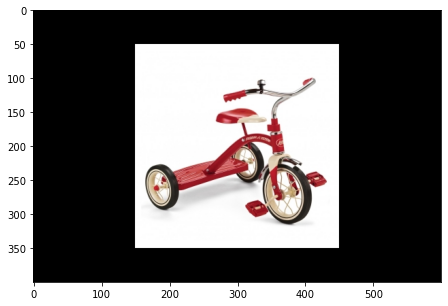

```python
# Create a large image and translate the tricycle image to the center
# Note that the slicing values must equal the width and height of the tricycle image
new_image = np.zeros((400, 600, 3), dtype=np.uint8)

rows, cols, ch = image.shape
width_spacing = (400 - rows) // 2
height_spacing = (600 - cols) // 2

# Note that the splicing values must match the size of the image
new_image[width_spacing:rows+width_spacing, height_spacing:cols+height_spacing] = image

plt.imshow(cv2.cvtColor(new_image, cv2.COLOR_BGR2RGB))
plt.show()
```

### resizing

OpenCV has a resize() function that will allow you to resize an images you are working with. The following is from the OpenCV documentation.

[Great Video on Resizing Images](https://www.youtube.com/watch?v=AqscP7rc8_M)

`cv2.resize(src, dsize[, dst[, fx[, fy[, interpolation]]]])`

Parameters:

[output not shown]

Note that there are different options for `interpolation`. This is used to decide how pixels are removed from an image if it is shinking and increasing in size. [Details on interpolation](https://docs.opencv.org/master/da/d54/group__imgproc__transform.html#ga5bb5a1fea74ea38e1a5445ca803ff121)

```
100%, shape = (300, 300, 3)
```

[figure not shown]

```
resize 50%, shape = (150, 150, 3)
```

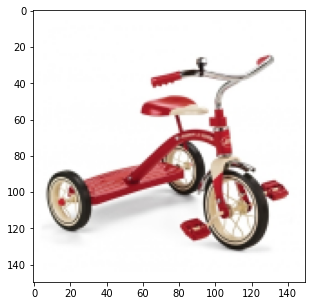

```
resize 25%, shape = (75, 75, 3)
```

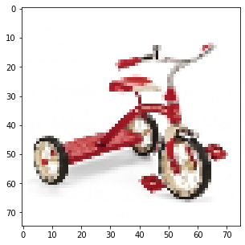

```
resize 200%, shape = (600, 600, 3)
```

[figure not shown]

```python
# Resize Example.  Note that resize returns a new numpy image

rows, cols, _ = image.shape

# Original image - notice the size of the image
print(f'100%, shape = {image.shape}')
plt.imshow(cv2.cvtColor(image, cv2.COLOR_BGR2RGB))
plt.show()

new_size = cv2.resize(image, (rows // 2, cols // 2))
print(f'resize 50%, shape = {new_size.shape}')
plt.imshow(cv2.cvtColor(new_size, cv2.COLOR_BGR2RGB))
plt.show()

new_size = cv2.resize(image, (rows // 4, cols // 4))
print(f'resize 25%, shape = {new_size.shape}')
plt.imshow(cv2.cvtColor(new_size, cv2.COLOR_BGR2RGB))
plt.show()

new_size = cv2.resize(image, (rows * 2, cols * 2))
print(f'resize 200%, shape = {new_size.shape}')
plt.imshow(cv2.cvtColor(new_size, cv2.COLOR_BGR2RGB))
plt.show()
```

### Flipping

Flipping an image is easy with the flip() function. Flip() has 3 arguments:

- **src** – input array.
- **dst** – output array of the same size and type as src.
- **flipCode** – a flag to specify how to flip the array; 0 means flipping around the x-axis and positive value (for example, 1) means flipping around y-axis. Negative value (for example, -1) means flipping around both axes (see the discussion below for the formulas).

[Flip Documentation](https://docs.opencv.org/2.4/modules/core/doc/operations_on_arrays.html#flip)

```
Flip on axis = 0
```

[figure not shown]

```
Flip on axis = 1
```

[figure not shown]

```
Flip on axis = -1
```

[figure not shown]

```python
# Flip() examples

new_image = cv2.flip(image, 0)
print('Flip on axis = 0')
plt.imshow(cv2.cvtColor(new_image, cv2.COLOR_BGR2RGB))
plt.show()

new_image = cv2.flip(image, 1)
print('Flip on axis = 1')
plt.imshow(cv2.cvtColor(new_image, cv2.COLOR_BGR2RGB))
plt.show()

new_image = cv2.flip(image, -1)
print('Flip on axis = -1')
plt.imshow(cv2.cvtColor(new_image, cv2.COLOR_BGR2RGB))
plt.show()
```

### Cropping

Cropping an image is best proformed using numpy's slicing feature.

[figure not shown]

```python
# crop from all sides of the image
shrink = 80  # Try 140
new_image = image[shrink:-shrink, shrink:-shrink]

f = plt.figure()
f.add_subplot(1, 2, 1)
plt.imshow(cv2.cvtColor(image, cv2.COLOR_BGR2RGB))
f.add_subplot(1,2, 2)
plt.imshow(cv2.cvtColor(new_image, cv2.COLOR_BGR2RGB))
plt.show(block=True)
```

### Rotation (OpenCV Function)

Rotation of an image is very easy in OpenCV, however there are issues with losing parts of an image. See the examples below.

```python
def rotateImage(image, angle, position=None):
    if (position == None):
        image_center = tuple(np.array(image.shape[1::-1]) / 2)
    else:
        image_center = position
    rot_mat = cv2.getRotationMatrix2D(image_center, angle, 1.0)
    result = cv2.warpAffine(image, rot_mat, image.shape[1::-1], flags=cv2.INTER_LINEAR)
    return result
```

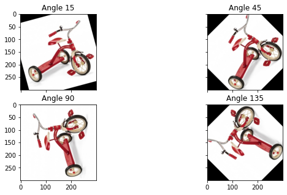

```python
# calling the above function
rot15 = rotateImage(image, 15)
rot45 = rotateImage(image, 45)
rot90 = rotateImage(image, 90)
rot135 = rotateImage(image, 135)

fig, axs = plt.subplots(2, 2)
axs[0, 0].imshow(cv2.cvtColor(rot15, cv2.COLOR_BGR2RGB))
axs[0, 0].set_title('Angle 15')
axs[0, 1].imshow(cv2.cvtColor(rot45, cv2.COLOR_BGR2RGB))
axs[0, 1].set_title('Angle 45')
axs[1, 0].imshow(cv2.cvtColor(rot90, cv2.COLOR_BGR2RGB))
axs[1, 0].set_title('Angle 90')
axs[1, 1].imshow(cv2.cvtColor(rot135, cv2.COLOR_BGR2RGB))
axs[1, 1].set_title('Angle 135')

for ax in axs.flat:
    ax.label_outer()

plt.show(block=True)
```

[figure not shown]

```python
# rotating NOT around the center of the image

rot15 = rotateImage(image, 15, (0, 0))
plt.imshow(cv2.cvtColor(rot15, cv2.COLOR_BGR2RGB))
plt.show()
```

### Rotation (Using Matrices)

Rotation can be handled with a rotation matrix. (We will be seeing matrices more later in the course.) Please read and watch the video below to understand how points can be rotated.

- [Rotation Matrix](https://en.wikipedia.org/wiki/Rotation_matrix)
- [Understanding Rotation Matrices](https://math.stackexchange.com/questions/363652/understanding-rotation-matrices)
- Video [Rotation Points Using Rotation Matrices](https://www.youtube.com/watch?v=OYuoPTRVzxY)

## Blending

OpenCV has a great function to blend two images together. It isn't the only method. The function is addWeighted().

The function is going to create a new image based on:

- the two images
- **alpha** a weighted value for the amount of image 1 to use in the new image
- **beta** a weighted value for the amount of image 2 to use in the new image

**Note**: the two images must be the same size!

- [OpenCV documentation on addWeighted](https://docs.opencv.org/2.4/modules/core/doc/operations_on_arrays.html#addweighted)
- [addWeighted() Example](https://pythonexamples.org/python-opencv-add-blend-two-images/)

```
Source image 1
```

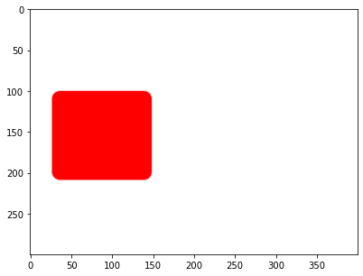

```
Source image 2
```

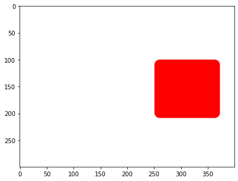

```
Blended Image
```

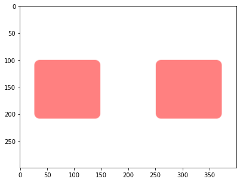

```python
# Example of blending two images
# Notice that the final results is a blend of both images but half brightness

src1 = cv2.imread('blend.png', cv2.IMREAD_COLOR)
src2 = cv2.flip(src1, 1)

# add or blend the images
dst = cv2.addWeighted(src1, 0.5, src2, 0.5, 0.0)

# save the output image
print('Source image 1')
plt.imshow(cv2.cvtColor(src1, cv2.COLOR_BGR2RGB))
plt.show()

print('Source image 2')
plt.imshow(cv2.cvtColor(src2, cv2.COLOR_BGR2RGB))
plt.show()

print('Blended Image')
plt.imshow(cv2.cvtColor(dst, cv2.COLOR_BGR2RGB))
plt.show()
```

## Reading

- [Flip Documentation](https://docs.opencv.org/2.4/modules/core/doc/operations_on_arrays.html#flip)
- [Geometric Transforms](https://opencv-python-tutroals.readthedocs.io/en/latest/py_tutorials/py_imgproc/py_geometric_transformations/py_geometric_transformations.html)
- [Resize() function](https://docs.opencv.org/master/da/d54/group__imgproc__transform.html#ga47a974309e9102f5f08231edc7e7529d)
- [addWeighted() Example](https://pythonexamples.org/python-opencv-add-blend-two-images/)
- [OpenCV documentation on addWeighted](https://docs.opencv.org/2.4/modules/core/doc/operations_on_arrays.html#addweighted)
- [Rotation Matrix](https://en.wikipedia.org/wiki/Rotation_matrix)
- [Understanding Rotation Matrices](https://math.stackexchange.com/questions/363652/understanding-rotation-matrices)
- Video [Rotation Points Using Rotation Matrices](https://www.youtube.com/watch?v=OYuoPTRVzxY)